# Analyse du Métabolisme Social

Analyse des Flux de Matières avec les Données Eurostat

Simon Jean

simon.jean@agroparistech.fr

AgroParisTech - CIRED - PSAE

## A. Objectifs de l’Atelier

- Accéder et préparer les données Eurostat sur les flux de matières
- Calculer les indicateurs métaboliques clés
- Visualiser et comparer les profils métaboliques
- Analyser les tendances et les schémas
- Simuler des interventions politiques de base

## B. Données

### 1. Acquisition

- On accède à Eurostat grâce au package `eurostat`
  - Trouvez le code du jeu de données pour les données MFA et les données de PIB

```r
# Téléchargement des données de Comptabilité de Flux de Matières
if(!(file.exists(here("data","external", "mfa_data.csv")))){
  mfa_data <- get_eurostat("env_ac_mfa",
                         time_format = "num")

  mfa_data_labeled = label_eurostat(mfa_data)


  write.csv(mfa_data_labeled,
            here('data', 'external', 'mfa_data.csv'),
            row.names = F)
}else{
  mfa_data_labeled = read.csv(here('data', 'external', 'mfa_data.csv'))
}



# Aperçu des données


if(!(file.exists(here("data","external", "gdp_data_filtered.csv")))){
  gdp_data <- get_eurostat("nama_10_gdp",
                        time_format = "num")

  gdp_data_filtered = gdp_data %>%
    filter(na_item == "B1GQ" &
           unit == "CP_MEUR")

  gdp_data_labeled = label_eurostat(gdp_data_filtered)
  gdp_data_full_labeled = label_eurostat(gdp_data)

  write.csv(gdp_data_labeled,
            here('data', 'external', 'gdp_data_filtered.csv'),
            row.names = F)
  write.csv(gdp_data_full_labeled,
            here('data', 'external', 'gdp_data_full_labeled.csv'),
            row.names = F)

}else{
  gdp_data_labeled = read.csv(here('data', 'external', 'gdp_data_filtered.csv'))
  gdp_data_full_labeled = read.csv(here('data', 'external', 'gdp_data_full_labeled.csv'))

}
```

- Biomass
- Metals
- Non-metallic minerals
- Fossil energy carriers
- Other products

```
Table: Catégorie : Biomass

|Material                                                                                                        |
|:---------------------------------------------------------------------------------------------------------------|
|Biomass                                                                                                         |
|Crops (excluding fodder crops)                                                                                  |
|Cereals                                                                                                         |
|Roots, tubers                                                                                                   |
|Sugar crops                                                                                                     |
|Pulses                                                                                                          |
|Nuts                                                                                                            |
|Oil-bearing crops                                                                                               |
|Vegetables                                                                                                      |
|Fruits                                                                                                          |
|Fibres                                                                                                          |
|Other crops (excluding fodder crops) n.e.c.                                                                     |
|Crop residues (used), fodder crops and grazed biomass                                                           |
|Crop residues (used)                                                                                            |
|Straw                                                                                                           |
|Other crop residues (sugar and fodder beet leaves, etc.)                                                        |
|Fodder crops and grazed biomass                                                                                 |
|Fodder crops (including biomass harvest from grassland)                                                         |
|Grazed biomass                                                                                                  |
|Wood                                                                                                            |
|Timber (industrial roundwood)                                                                                   |
|Wood fuel and other extraction                                                                                  |
|Wild fish catch, aquatic plants and animals, hunting and gathering                                              |
|Wild fish catch                                                                                                 |
|All other aquatic animals and plants                                                                            |
|Hunting and gathering                                                                                           |
|Live animals and animal products (excluding wild fish, aquatic plants and animals, hunted and gathered animals) |
|Live animals (excluding wild fish, aquatic plants and animals, hunted and gathered animals)                     |
|Meat and meat preparations                                                                                      |
|Dairy products, birds' eggs, and honey                                                                          |
|Other products from animals (animal fibres, skins, furs, leather, etc.)                                         |
|Products mainly from biomass                                                                                    |
```

```
Table: Catégorie : Metals

|Material                                         |
|:------------------------------------------------|
|Metal ores (gross ores)                          |
|Iron                                             |
|Non-ferrous metal                                |
|Copper                                           |
|Nickel                                           |
|Lead                                             |
|Zinc                                             |
|Tin                                              |
|Gold, silver, platinum and other precious metals |
|Bauxite and other aluminium                      |
|Uranium and thorium                              |
|Other non-ferrous metals                         |
|Products mainly from metals                      |
```

```
Table: Catégorie : Non-metallic minerals

|Material                                                                                           |
|:--------------------------------------------------------------------------------------------------|
|Non-metallic minerals                                                                              |
|Marble, granite, sandstone, porphyry, basalt, other ornamental or building stone (excluding slate) |
|Chalk and dolomite                                                                                 |
|Slate                                                                                              |
|Chemical and fertiliser minerals                                                                   |
|Salt                                                                                               |
|Limestone and gypsum                                                                               |
|Clays and kaolin                                                                                   |
|Sand and gravel                                                                                    |
|Other non-metallic minerals n.e.c.                                                                 |
|Products mainly from non metallic minerals                                                         |
```

```
Table: Catégorie : Fossil energy carriers

|Material                                                                                          |
|:-------------------------------------------------------------------------------------------------|
|Fossil energy materials/carriers                                                                  |
|Coal and other solid energy materials/carriers                                                    |
|Lignite (brown coal)                                                                              |
|Hard coal                                                                                         |
|Oil shale and tar sands                                                                           |
|Peat                                                                                              |
|Liquid and gaseous energy materials/carriers                                                      |
|Crude oil, condensate and natural gas liquids (NGL)                                               |
|Natural gas                                                                                       |
|Fuels bunkered (imports: by resident units abroad); (exports: by non-resident units domestically) |
|Fuel for land transport                                                                           |
|Fuel for water transport                                                                          |
|Fuel for air transport                                                                            |
|Products mainly from fossil energy products                                                       |
```

```
Table: Catégorie : Other products

|Material                                        |
|:-----------------------------------------------|
|Other products                                  |
|Waste for final treatment and disposal          |
|Stage of manufacturing - finished products      |
|Stage of manufacturing - raw products           |
|Stage of manufacturing - semi-finished products |
```

## C. Visualisation des indicateurs par pays

1. Répartissez vous en groupe de deux
2. Ecrivez une fonction pour représenter les indicateurs clés de l’analyse MFA comme chez Magalhaes (ou dans le MFA): Domestic extraction, Direct material inputs, domestic consumption, imports and exports
3. Choisissez un pays dans l’UE et sortez son profil métabollique dans les dernières années
- Code
- DE

```r
summary_classes = c('Biomass', 'Metal ores (gross ores)', 'Non-metallic minerals',
                    'Fossil energy materials/carriers', 'Other products')

visualizer = function(country, variable, data_ = mfa_data_labeled){
  p = data_%>%
    subset(geo == country)%>%
    subset(unit == "Tonnes per capita")%>% # On garde les tonnes par tête
    subset(indic_env == variable)%>% # On
    subset(material %in% summary_classes)%>%
    ggplot(aes(x=TIME_PERIOD, y=values, fill = material, color = material))+
    geom_area()+
    scale_fill_manual(values = palette_mfa)+
    scale_color_manual(values = palette_mfa)+
    custom_theme()+
    ylab('t/cap/yr')+
    xlab('Year')+
    labs(color=NULL,
         fill = NULL)+
    ggtitle(paste(country, ' - ', variable))

  return(p)
}
```

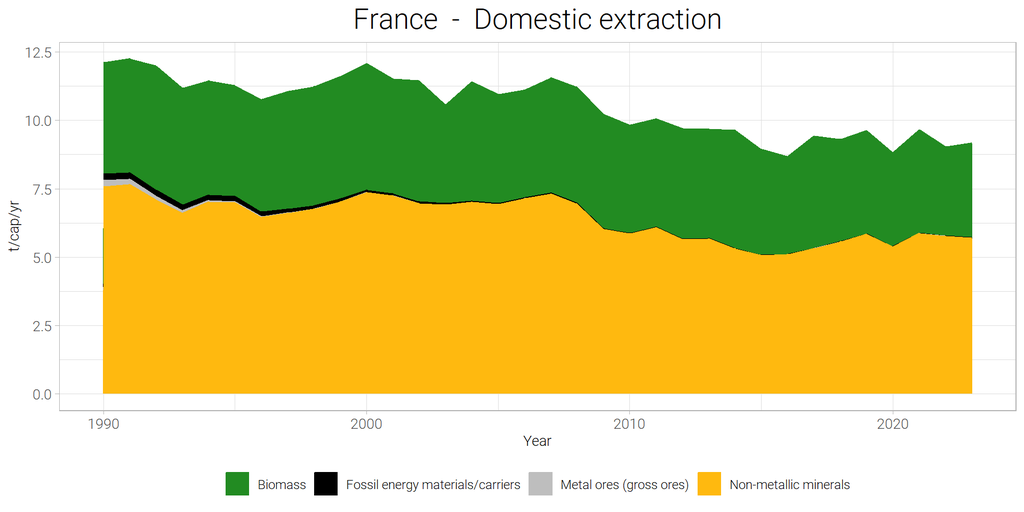

### DMI

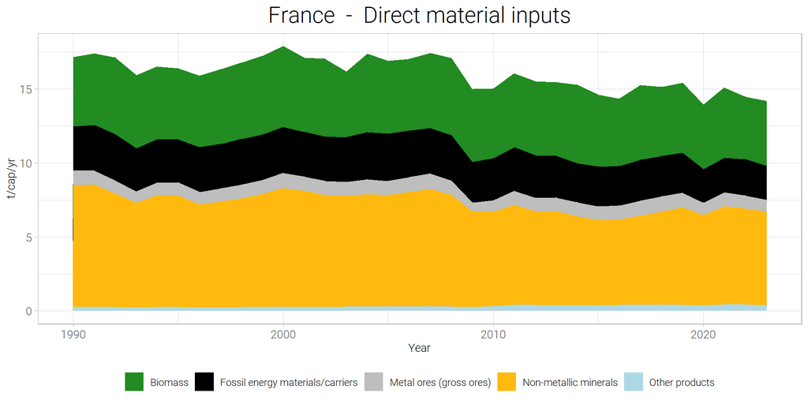

### DMC

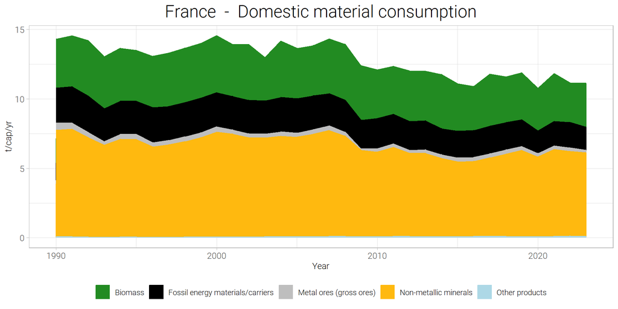

### Imports

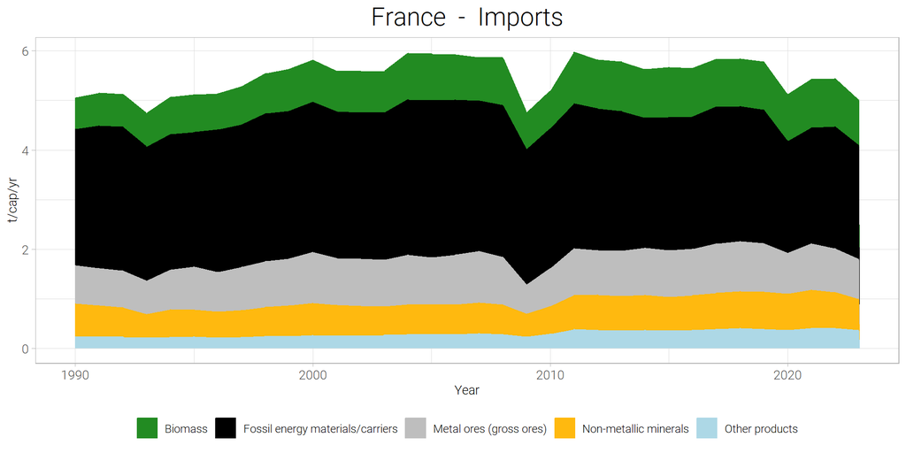

### Exports

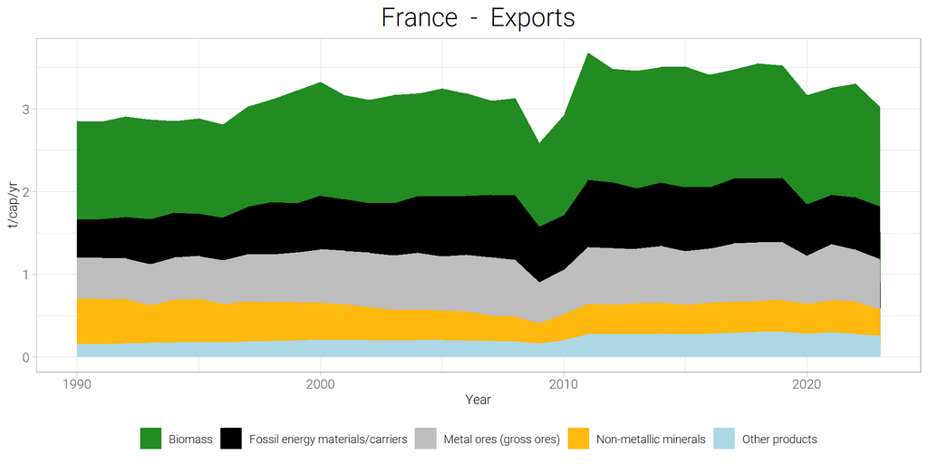

## D. Comparaison des profils pays dans le temps

### 1. Par indicateurs

```r
countries_to_compare = c('France', 'Spain', 'Germany', 'Estonia', 'Italy', 'Greece','Finland')

palette_countries = palette.colors(length(countries_to_compare))

comparison_visualiser = function(countries = countries_to_compare,
                                 indic_env_,
                                 unit_){
 p = mfa_data_labeled%>%
   subset(geo %in% countries_to_compare)%>%
   subset(indic_env== indic_env_)%>%
   subset(unit == unit_)%>%
   subset(material %in% summary_classes)%>%
   group_by(geo,TIME_PERIOD)%>%
   mutate(overall = sum(values,  na.rm = TRUE))%>%
   ungroup()%>%
   select(c('TIME_PERIOD', 'geo', 'overall'))%>%
   ggplot(aes(x = TIME_PERIOD, y = overall, color = geo))+
   geom_line(linewidth=1)+
   scale_color_manual(values = unname(palette_countries))+
   custom_theme()+
   ylab(paste(indic_env_,"in", unit_))+
   xlab(" ")+
   labs(color=NULL)
 return(p)
}
```

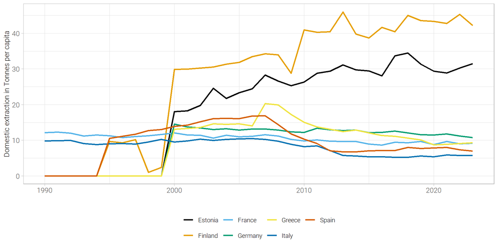

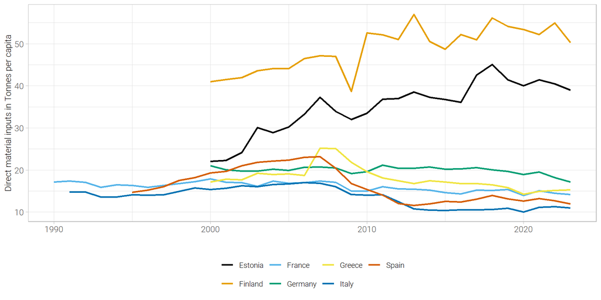

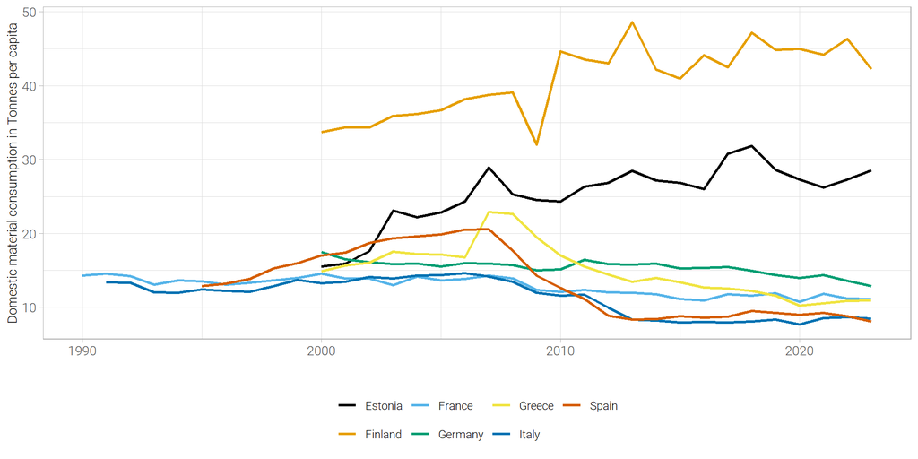

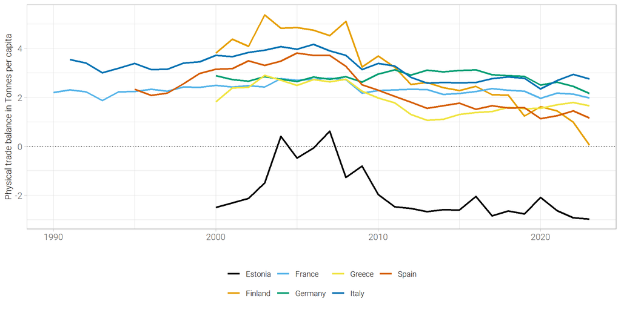

### 2. Productivité des ressources

$$\frac{PIB}{DMI}$$

1. Choisissez un échantillon de pays utile à comparer en Europe
2. Calculez leurs productivités des ressources
3. Montrez leur évolution dans le temps

```r
countries_to_compare = c('France', 'Spain', 'Germany', 'Estonia', 'Italy', 'Greece','Finland')
palette_countries = palette.colors(length(countries_to_compare))

efficiency_data = mfa_data_labeled%>%
  subset(geo %in% countries_to_compare)%>%
  subset(indic_env== "Direct material inputs")%>%
  subset(unit == 'Thousand tonnes')%>%
  subset(material %in% summary_classes)%>%
  group_by(geo,TIME_PERIOD)%>%
  mutate(overall = sum(values))%>%
  ungroup()%>%
  select(c('TIME_PERIOD', 'geo', 'overall'))
```

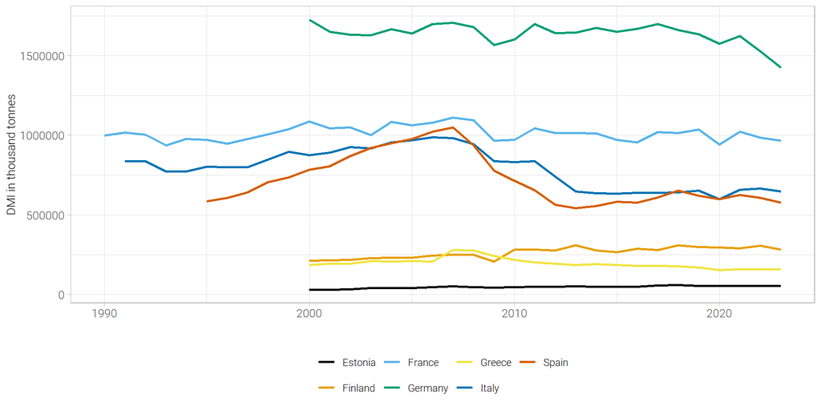

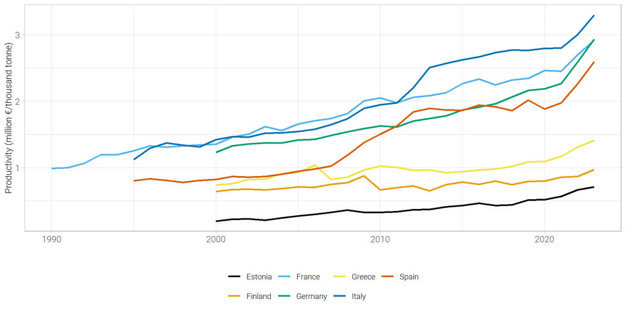

### 3. Efficacité matérielle

$$\frac{PIB}{DMC}$$

1. En utilisant les mêmes techniques, calculez l’efficacité matérielle
2. Quelle est la différence entre les deux mesures?
- Code
- Illustration

```r
performance = function(indic_env_, indicator, countries = countries_to_compare){
  p = mfa_data_labeled%>%
  subset(geo %in% countries)%>%
  subset(indic_env== indic_env_)%>%
  subset(unit == 'Thousand tonnes')%>%
  subset(material %in% summary_classes)%>%
  group_by(geo,TIME_PERIOD)%>%
  mutate(overall = sum(values))%>%
  ungroup()%>%
  select(c('TIME_PERIOD', 'geo', 'overall'))%>%
  full_join(gdp_data_labeled, by = c("TIME_PERIOD", "geo"))%>%
  subset(geo %in% countries_to_compare)%>%
  drop_na()%>%
  mutate(new_var= values/overall)%>%
  ggplot(aes(x = TIME_PERIOD, y = new_var, color = geo))+
  geom_line(linewidth=1)+
  scale_color_manual(values = unname(palette_countries))+
  custom_theme()+
  ylab(indicator)+
  xlab(" ")+
  labs(color=NULL)

  return(p)
}
```

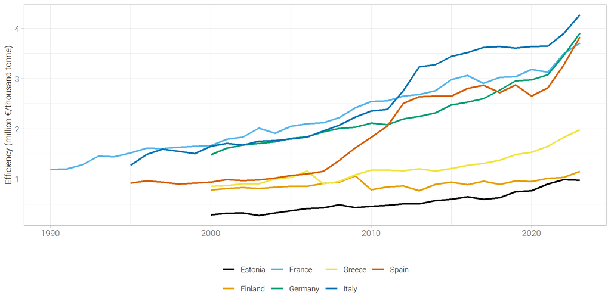

### Différence entre les deux mesures

Productivité matérielle (Resource Productivity ou RP):

- Quantité de valeur économique (PIB) générée par unité de matière entrante dans l’économie (DMI).
- capacité à créer de la valeur à partir des matières qui entrent dans le système économique.
- capacité à créer de la valeur à partir des matières qui entrent dans le système économique.
- indicateur d’efficience économique orienté vers la production.

Efficacité matérielle (Material Efficiency ou ME):

- quantité de valeur économique (PIB) générée par unité de matière effectivement consommée par l’économie (DMC).
- focalise sur l’utilisation interne des matières pour créer de la valeur.
- exclut les matières qui sont simplement réexportées
- indicateur d’efficience écologique orienté vers la consommation.

peuvent diverger significativement pour les économies qui jouent un rôle important dans le commerce international de matières premières ou semi-transformées

### 4. Découplages matériaux ?

1. Calculez les taux de croissance des indicateurs : PIB et métaboliques
2. Tracez graphiquement leur évolutions

```r
growth_dmi = mfa_data_labeled%>%
  subset(geo %in% countries_to_compare)%>%            # Pays que l'on souhaite conserver
  subset(indic_env == "Direct material inputs")%>%    # Grandeur considérée
  subset(unit=='Thousand tonnes')%>%                  # Unités de mesure
  subset(material %in% summary_classes)%>%            # Pour les classes de matériaux aggrégées
  group_by(geo, TIME_PERIOD)%>%                       # Groupement par couple année/pays pour sommer sur les matériaux agrégés
  mutate(overall = sum(values))%>%
  ungroup()%>%                                        # Degroup
  select(indic_env, geo, TIME_PERIOD, overall)%>%     # Selection des variables
  group_by(geo) %>%                                   # Grouping by geo (or another grouping variable)
  arrange(TIME_PERIOD) %>%                            # Ensure the data is in time order
  mutate(DMI = (overall / lag(overall) - 1) * 100) %>% # Compute growth rate in percent
  ungroup()%>%
  distinct()%>%
  subset(DMI!=0)
```

```r
growth_gdp = gdp_data_labeled%>%
  subset(geo %in% countries_to_compare)%>%            # Pays que l'on souhaite conserver
  group_by(geo) %>%                                   # Grouping by geo (or another grouping variable)
  arrange(TIME_PERIOD) %>%                            # Ensure the data is in time order
  mutate(GDP = (values / lag(values) - 1) * 100) %>% # Compute growth rate in percent
  ungroup()%>%
  distinct()
```

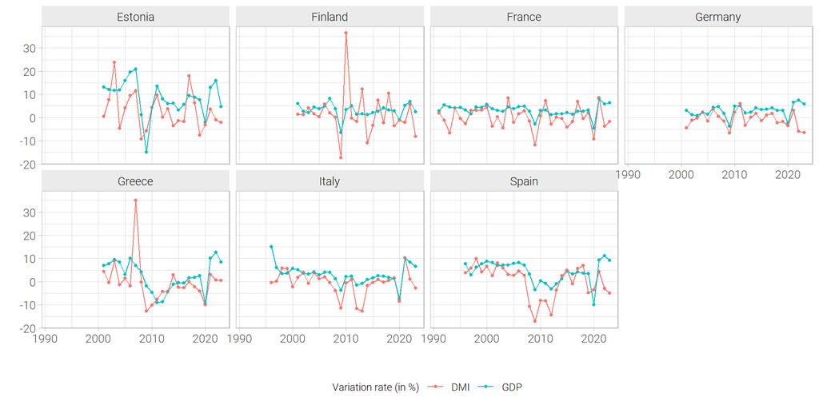

### 5. Evolutions des demandes de matériaux liés à la transition

- Cuivre :
  - Essentiel pour les infrastructures électriques (câblage, moteurs, transformateurs) et les réseaux intelligents.
  - Forte demande mondiale due à l’électrification et aux énergies renouvelables, entraînant des risques de tensions d’approvisionnement.
  - La concentration géographique de certaines réserves peut accentuer la vulnérabilité aux perturbations géopolitiques.
- Nickel :
  - Batteries lithium-ion, cruciales pour le stockage d’énergie et les véhicules électriques.
- Or, argent, platine et métaux précieux :
  - Electronique de pointe
  - Rareté et la concentration des mines dans certains pays posent des risques d’approvisionnement et de volatilité des prix.
- Bauxite et autre Aluminium :
  - Transformation de la bauxite en aluminium
  - Légèreté et résistance: matériau de choix pour l’automobile, l’aéronautique et les infrastructures renouvelables.
- Uranium Thorium
  - Sources de combustible pour la production d’énergie nucléaire, offrant une solution bas carbone pour la transition énergétique.
  - Disponibilité de thorium pourrait offrir des alternatives: nécessite encore des développements technologiques et réglementaires.
- Autres métaux non ferreux :
  - Divers éléments critiques utilisés dans la fabrication de composants électroniques, batteries, et technologies renouvelables.

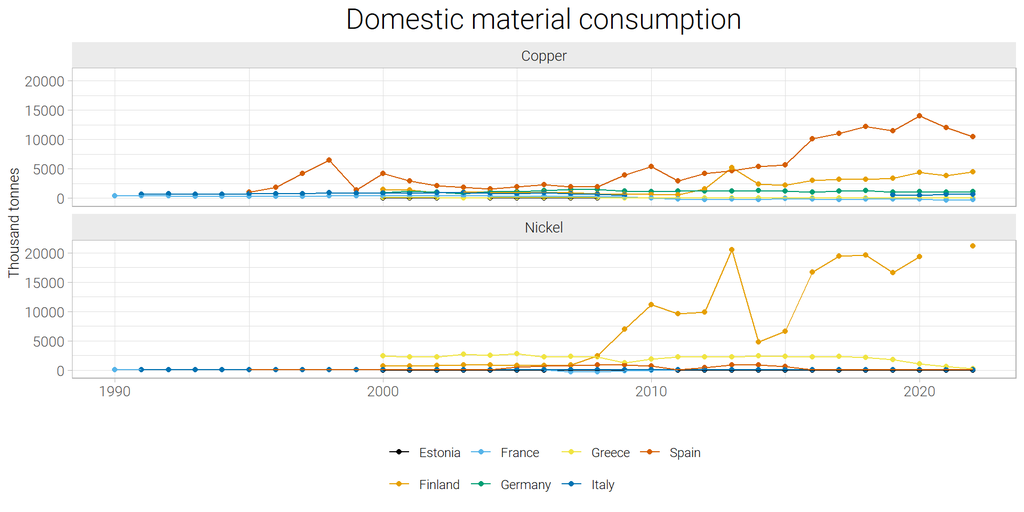

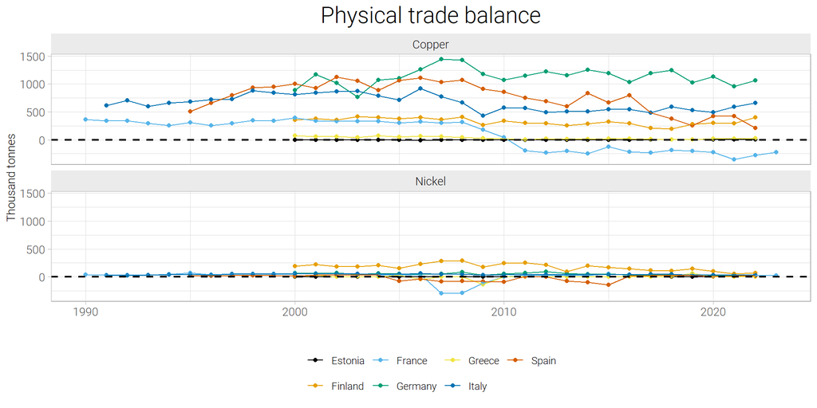